# profilepoint analysis siliceous bedrock

fabian gruber

October 24, 2017

How do those points that were classified correctly by the geologic map differ from those identified by the surveyors?

0 1 6 14

[1] “OBB error with all predictors of allpreds is 0.35” [1] “OBB error with all predictors of roughness is 0.4” [1] “OBB error with all predictors of localterrain is 0.45”

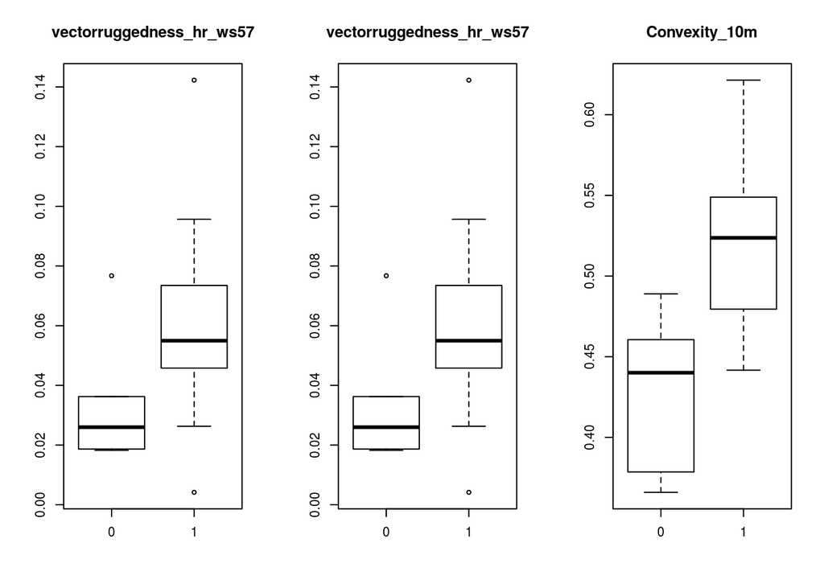

How are these points morphometrically different from others For instance different to till in general

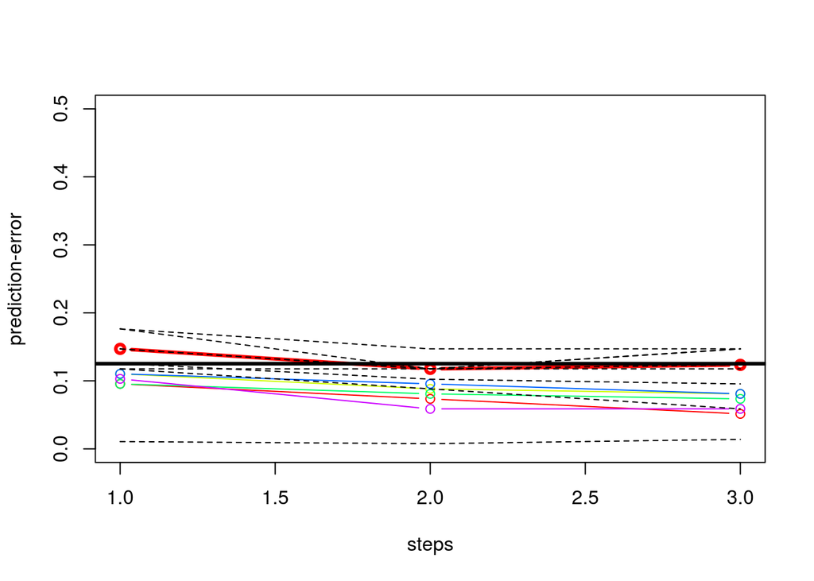

[1] “Prediction error at end is: 0.147058823529412” [2] “Prediction error at end is: 0.117647058823529” [3] “Prediction error at end is: 0.123529411764706”

| k 1 | k 2 | k 3 | k 4 | k 5 |
| --- | --- | --- | --- | --- |
| terraintexture_hr_ws29_tp25 | geom_hr_L3_fl1_rplipmps_UE_hr_5cells_hr | TRI_hr_ws43 | TRI_hr_ws43 | Slope_50m |
| Total_Curvature_50m | minic_DTM_50m_avg_ws11_50m | TRI_hr_ws4 | TRI_hr_ws4 | maxic_ws19_hr_hr |
| vectorruggedness_hr_ws25 | minic_ws3_hr_hr | geom_hr_L3_fl10_rplipdominance_UE_hr_5cells_hr | geom_hr_L3_fl10_rplipsimpson_UE_hr_60cells_hr | CrossSectionalCurvature_hr |

[1] “OBB error with all predictors of allpreds is 0.117647058823529”

|  | SB | TG | MeanDecreaseAccuracy | MeanDecreaseGini |
| --- | --- | --- | --- | --- |
| geom_hr_L50m_fl10_rplipsimpson_UE_hr_60cells_hr | 0.0055349 | 0.0006896 | 0.0013064 | 0.2839323 |
| slope_ws29_hr_hr | 0.0057546 | 0.0008351 | 0.0012666 | 0.2105116 |
| profc_DTM_50m_avg_ws11_50m | 0.0028620 | 0.0009279 | 0.0011401 | 0.1693868 |
| longc_DTM_50m_avg_ws3_50m | 0.0032731 | 0.0008018 | 0.0011301 | 0.3917307 |
| VerticalDistancetoChannelNetwork_10m | 0.0022905 | 0.0008563 | 0.0010668 | 0.2629182 |
| maxic_DTM_50m_avg_ws9_50m | 0.0013278 | 0.0010222 | 0.0010590 | 0.3684124 |
| slope_ws5_hr_hr | 0.0018937 | 0.0008455 | 0.0009567 | 0.2407514 |
| Modified_Catchment_Area_50m | 0.0026342 | 0.0007626 | 0.0009527 | 0.2287322 |
| slope_ws11_10m | 0.0019209 | 0.0008365 | 0.0009425 | 0.2249778 |
| TRI_hr_ws22 | 0.0018667 | 0.0007422 | 0.0008913 | 0.1131190 |

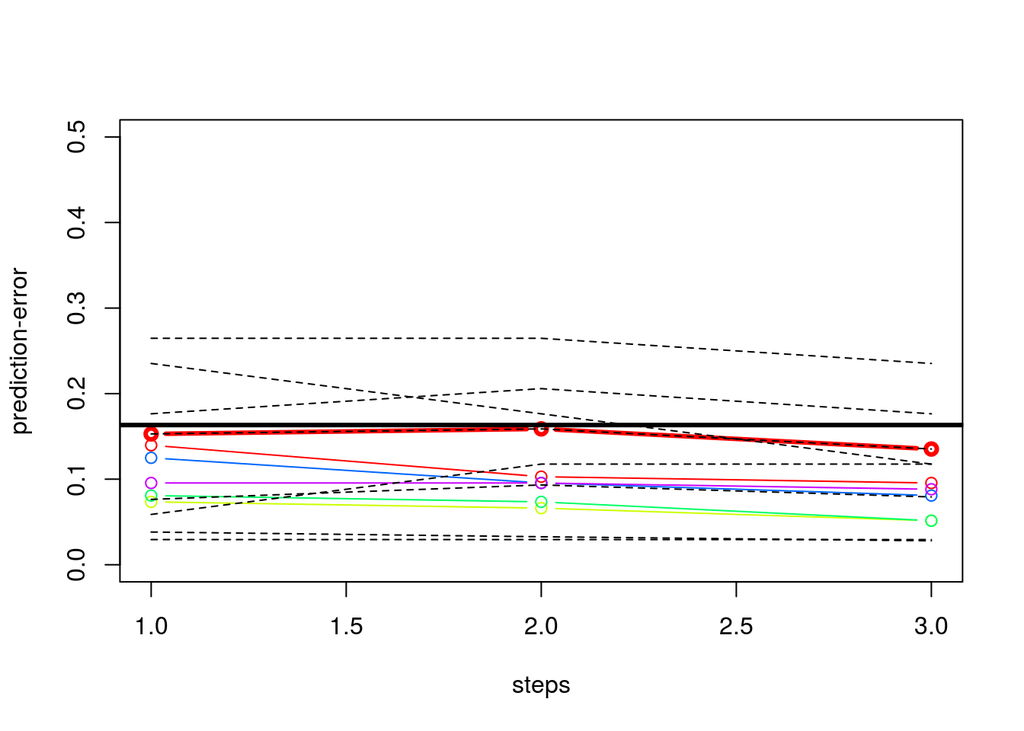

[1] “Prediction error at end is: 0.152941176470588” [2] “Prediction error at end is: 0.158823529411765” [3] “Prediction error at end is: 0.135294117647059”

| k 1 | k 2 | k 3 | k 4 | k 5 |
| --- | --- | --- | --- | --- |
| geom_hr_L3_fl10_rpliprichness_UE_hr_10cells_hr | geom_hr_L50m_fl10_rpliprichness_UE_hr_40cells_hr | TRI_hr_ws43 | geom_hr_L3_fl1_rplipmps_UE_hr_5cells_hr | geom_hr_L50m_fl1_rplipsimpson_UE_hr_5cells_hr |
| TRI_hr_ws4 | TRI_hr_ws6 | TRI_hr_ws4 | TRI_hr_ws49 | geom_hr_L3_fl1_rplipmps_UE_hr_5cells_hr |
| geom_hr_L3_fl10_rplippatchdensity_UE_hr_60cells_hr | TRI_hr_ws4 | geom_hr_L3_fl10_rplipsimpson_UE_hr_60cells_hr | geom_hr_L3_fl10_rplipsimpson_UE_hr_60cells_hr | TRI_hr_ws35 |

[1] “OBB error with all predictors of roughness is 0.111764705882353”

|  | SB | TG | MeanDecreaseAccuracy | MeanDecreaseGini |
| --- | --- | --- | --- | --- |
| vectorruggedness_hr_ws43 | 0.0005721 | 0.0024590 | 0.0021655 | 0.1491943 |
| TRI_hr_ws45 | 0.0039111 | 0.0017107 | 0.0019279 | 0.2173341 |
| geom_hr_L3_fl1_rplipedgedensity_UE_hr_60cells_hr | 0.0004270 | 0.0017992 | 0.0016727 | 0.2441287 |
| TRI_hr_ws19 | 0.0035747 | 0.0014443 | 0.0016485 | 0.3504241 |
| geom_hr_L50m_fl1_rplippatchnum_UE_hr_10cells_hr | -0.0001286 | 0.0017975 | 0.0015968 | 0.1618161 |
| vectorruggedness_hr_ws39 | -0.0001968 | 0.0018248 | 0.0015929 | 0.1772294 |
| geom_hr_L50m_fl1_rplipdominance_UE_hr_20cells_hr | 0.0061041 | 0.0011470 | 0.0015012 | 0.3467684 |
| TRI_hr_ws18 | 0.0055336 | 0.0008857 | 0.0014494 | 0.3076024 |
| geom_hr_L50m_fl1_rplippatchdensity_UE_hr_10cells_hr | -0.0005357 | 0.0016793 | 0.0014279 | 0.0378306 |
| geom_hr_L50m_fl10_rplipsimpson_UE_hr_60cells_hr | 0.0058127 | 0.0007539 | 0.0013776 | 0.3881271 |

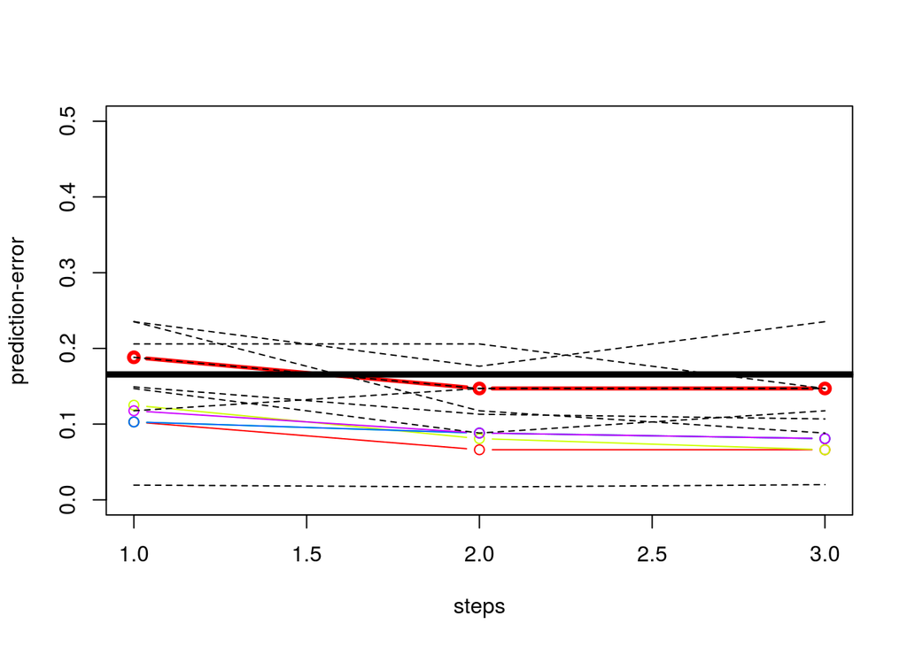

[1] “Prediction error at end is: 0.188235294117647” [2] “Prediction error at end is: 0.147058823529412” [3] “Prediction error at end is: 0.147058823529412”

| k 1 | k 2 | k 3 | k 4 | k 5 |
| --- | --- | --- | --- | --- |
| longc_ws23_hr_hr | longc_DTM_50m_avg_ws11_50m | dtm_hr_CONVEX_r5 | Slope_50m | longc_ws23_hr_hr |
| minic_DTM_50m_avg_ws11_50m | planc_ws3_10m | slope_ws29_hr_hr | Profile_Curvature_hr | Slope_50m |
| longc_DTM_50m_avg_ws5_50m | slope_ws7_10m | profc_DTM_50m_avg_ws11_50m | dtm_hr_CONVEX_r30 | maxic_ws19_hr_hr |

[1] “OBB error with all predictors of localterrain is 0.123529411764706”

|  | SB | TG | MeanDecreaseAccuracy | MeanDecreaseGini |
| --- | --- | --- | --- | --- |
| minic_ws23_hr_hr | 0.0015889 | 0.0024142 | 0.0023100 | 0.4562870 |
| longc_DTM_50m_avg_ws11_50m | 0.0024620 | 0.0022921 | 0.0022872 | 0.5298448 |
| minic_ws19_hr_hr | 0.0034833 | 0.0021598 | 0.0022811 | 0.4469371 |
| minic_ws5_10m | -0.0001730 | 0.0024355 | 0.0021611 | 0.3373443 |
| maxic_DTM_50m_avg_ws11_50m | 0.0060938 | 0.0016964 | 0.0021468 | 0.5056773 |
| minic_ws13_hr_hr | 0.0002826 | 0.0021651 | 0.0019678 | 0.2979797 |
| profc_DTM_50m_avg_ws11_50m | 0.0024517 | 0.0019050 | 0.0019630 | 0.4078459 |
| longc_DTM_50m_avg_ws9_50m | -0.0012833 | 0.0021357 | 0.0018354 | 0.3270425 |
| maxic_DTM_50m_avg_ws9_50m | 0.0061771 | 0.0013117 | 0.0018149 | 0.5689098 |
| slope_DTM_50m_avg_ws3_50m | 0.0019778 | 0.0017015 | 0.0017619 | 0.3842638 |

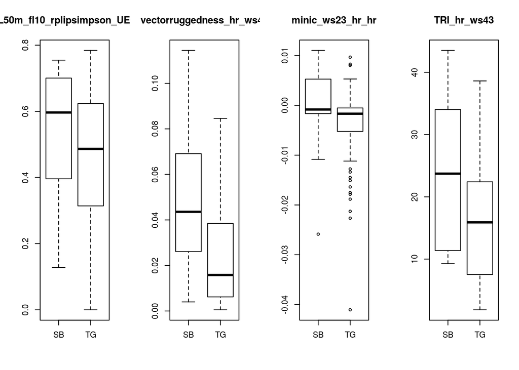

How does this compare to the differences between the units on the geological map?

[1] “OBB error with all predictors of allpreds is 0.0861020121665887”

|  | SB | TG | MeanDecreaseAccuracy | MeanDecreaseGini |
| --- | --- | --- | --- | --- |
| elev_ws11_10m | 0.0192152 | 0.0272455 | 0.0245339 | 51.24813 |
| elev_ws5_10m | 0.0211517 | 0.0260641 | 0.0244116 | 52.97783 |
| elev_ws15_10m | 0.0203979 | 0.0257849 | 0.0239587 | 56.54231 |
| elev_ws3_10m | 0.0173399 | 0.0236127 | 0.0214992 | 46.29069 |
| Channel_Network_Base_Level_hr | 0.0128883 | 0.0242677 | 0.0204434 | 39.70856 |
| ChannelNetworkBaseLevel_10m | 0.0017198 | 0.0240574 | 0.0165222 | 30.12524 |
| Vertical_Distance_to_Channel_Network_50m | 0.0064459 | 0.0119505 | 0.0101022 | 24.05296 |
| Standardized_Height_50m | 0.0083067 | 0.0091970 | 0.0089022 | 28.17490 |
| TRI_hr_ws48 | 0.0072543 | 0.0056862 | 0.0062086 | 19.44652 |
| TRI_hr_ws46 | 0.0077527 | 0.0053579 | 0.0061680 | 14.04362 |

[1] “OBB error with all predictors of roughness is 0.16”

|  | SB | TG | MeanDecreaseAccuracy | MeanDecreaseGini |
| --- | --- | --- | --- | --- |
| TRI_hr_ws49 | 0.0125000 | 0.0116960 | 0.0119640 | 25.09875 |
| TRI_hr_ws50 | 0.0103150 | 0.0116495 | 0.0112119 | 15.22383 |
| TRI_hr_ws48 | 0.0119104 | 0.0104592 | 0.0109305 | 22.40568 |
| TRI_hr_ws41 | 0.0121693 | 0.0097974 | 0.0105825 | 31.51698 |
| TRI_hr_ws46 | 0.0114280 | 0.0083809 | 0.0093887 | 19.47218 |
| TRI_hr_ws44 | 0.0120687 | 0.0075069 | 0.0090471 | 19.30708 |
| TRI_hr_ws47 | 0.0090512 | 0.0088333 | 0.0089167 | 20.99593 |
| TRI_hr_ws43 | 0.0109434 | 0.0068693 | 0.0082114 | 18.82534 |
| TRI_hr_ws40 | 0.0107559 | 0.0067662 | 0.0081175 | 25.16518 |
| TRI_hr_ws45 | 0.0093735 | 0.0071356 | 0.0078985 | 15.58170 |

[1] “OBB error with all predictors of localterrain is 0.154313771335048”

|  | SB | TG | MeanDecreaseAccuracy | MeanDecreaseGini |
| --- | --- | --- | --- | --- |
| maxic_DTM_50m_avg_ws11_50m | 0.0079775 | 0.0278554 | 0.0211600 | 57.39053 |
| longc_DTM_50m_avg_ws11_50m | 0.0057546 | 0.0185989 | 0.0142710 | 38.24974 |
| slope_ws11_10m | 0.0185954 | 0.0111483 | 0.0136456 | 55.38502 |
| maxic_DTM_50m_avg_ws9_50m | 0.0066902 | 0.0162320 | 0.0129938 | 43.62683 |
| profc_DTM_50m_avg_ws11_50m | 0.0054994 | 0.0160987 | 0.0125338 | 34.91701 |
| slope_ws15_10m | 0.0157009 | 0.0096449 | 0.0117018 | 49.12935 |
| slope_ws7_10m | 0.0169077 | 0.0081939 | 0.0111187 | 46.05637 |
| slope_ws29_hr_hr | 0.0128509 | 0.0077014 | 0.0094394 | 41.38903 |
| slope_ws23_hr_hr | 0.0141580 | 0.0069524 | 0.0093584 | 37.87611 |
| longc_DTM_50m_avg_ws9_50m | 0.0046438 | 0.0107736 | 0.0087206 | 33.24524 |

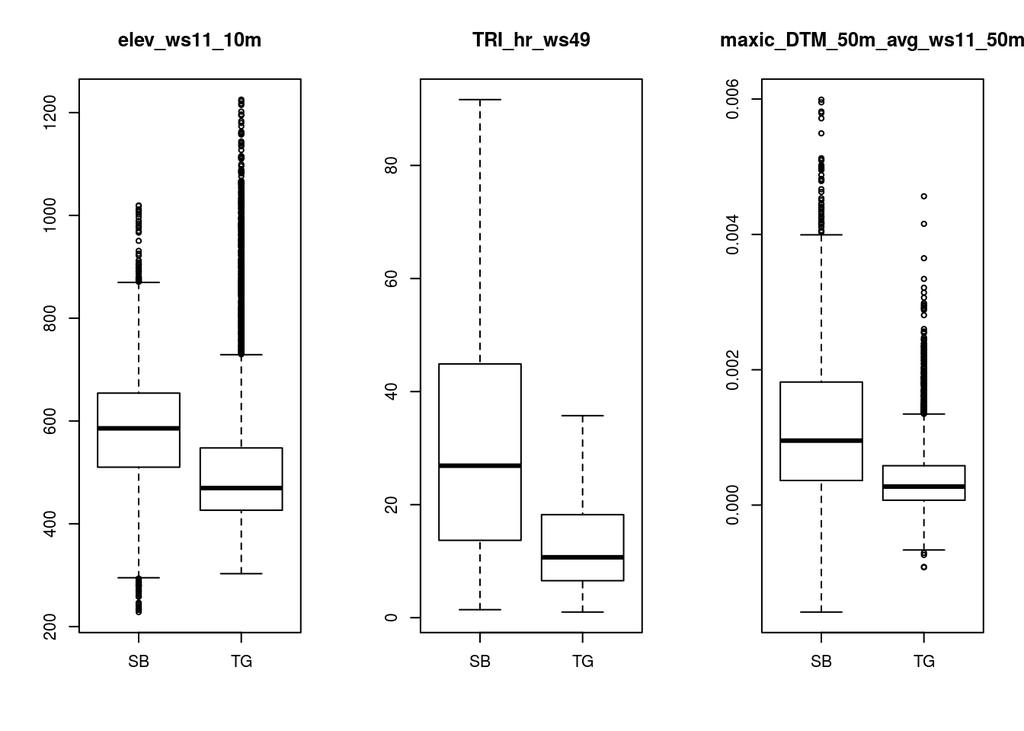

How about slope deposits

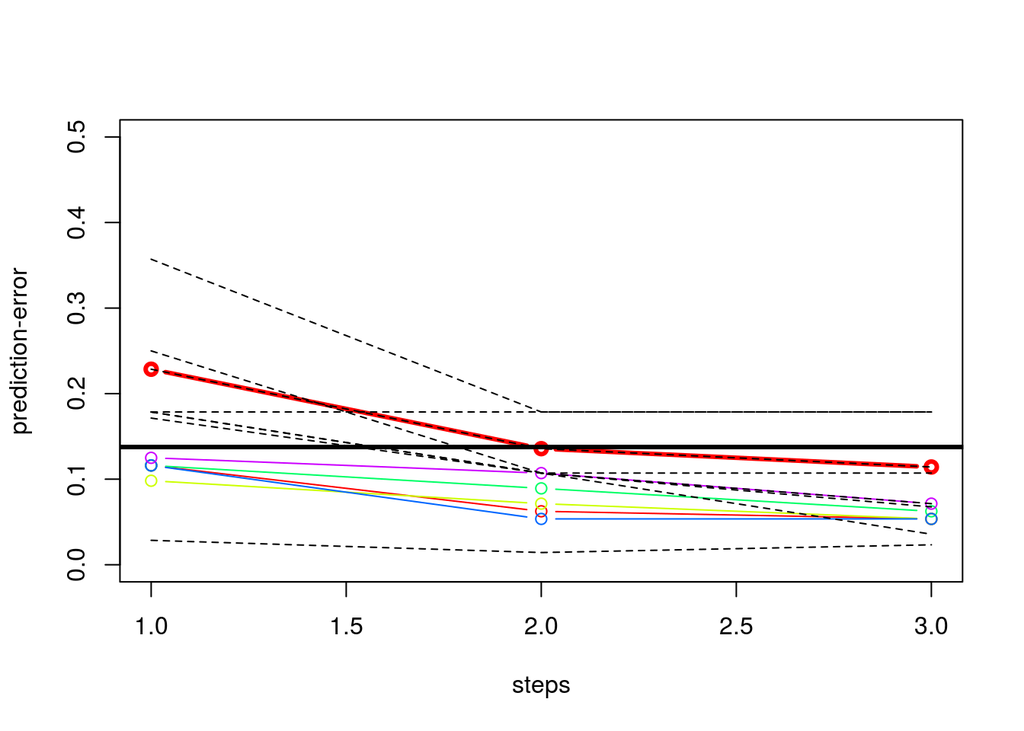

[1] “Prediction error at end is: 0.228571428571429” [2] “Prediction error at end is: 0.135714285714286” [3] “Prediction error at end is: 0.114285714285714”

| k 1 | k 2 | k 3 | k 4 | k 5 |
| --- | --- | --- | --- | --- |
| Mass_Balance_Index_50m | geom_hr_L3_fl1_rpliprichness_UE_hr_20cells_hr | geom_hr_L3_fl1_rplippatchdensity_UE_hr_5cells_hr | Tangential_Curvature_50m | geom_hr_L3_fl1_rplipedgedensity_UE_hr_20cells_hr |
| Channel_Network_Base_Level_50m | maxic_DTM_50m_avg_ws11_50m | geom_hr_L3_fl10_rplipsimpson_UE_hr_60cells_hr | ChannelNetworkBaseLevel_10m | geom_hr_L50m_fl10_rplipshannon_UE_hr_60cells_hr |
| maxic_DTM_50m_avg_ws11_50m | General_Curvature_50m | geom_hr_L3_fl10_rpliprichness_UE_hr_40cells_hr | Channel_Network_Base_Level_50m | geom_hr_L50m_fl1_rplipmps_UE_hr_60cells_hr |

[1] “OBB error with all predictors of allpreds is 0.121428571428571”

|  | SB | SD | MeanDecreaseAccuracy | MeanDecreaseGini |
| --- | --- | --- | --- | --- |
| Channel_Network_Base_Level_50m | 0.0094025 | 0.0034310 | 0.0041720 | 0.5168034 |
| ChannelNetworkBaseLevel_10m | 0.0065142 | 0.0034714 | 0.0037875 | 0.4703223 |
| geom_hr_L3_fl10_rplipsimpson_UE_hr_60cells_hr | 0.0091694 | 0.0024615 | 0.0035496 | 0.6070291 |
| Catchment_slope_50m | 0.0081185 | 0.0026661 | 0.0034372 | 0.3637313 |
| maxic_DTM_50m_avg_ws11_50m | 0.0091883 | 0.0019566 | 0.0030184 | 0.4080910 |
| elev_ws3_10m | 0.0025596 | 0.0030355 | 0.0030090 | 0.2087977 |
| longc_DTM_50m_avg_ws11_50m | 0.0069535 | 0.0018514 | 0.0026275 | 0.5086546 |
| profc_DTM_50m_avg_ws11_50m | 0.0054088 | 0.0019073 | 0.0023131 | 0.5844495 |
| minic_ws29_hr_hr | 0.0088549 | 0.0012346 | 0.0022643 | 0.5199247 |
| Channel_Network_Base_Level_hr | 0.0028588 | 0.0020818 | 0.0022609 | 0.2574954 |

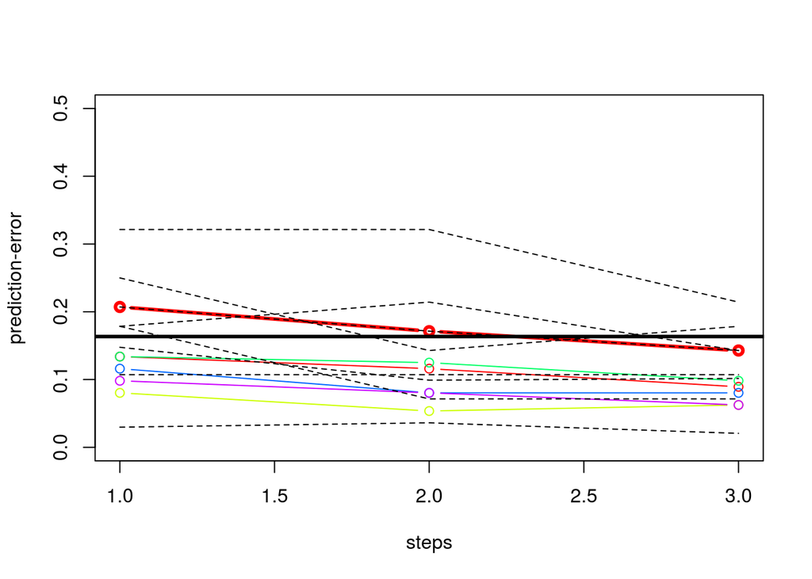

[1] “Prediction error at end is: 0.207142857142857” [2] “Prediction error at end is: 0.171428571428571” [3] “Prediction error at end is: 0.142857142857143”

| k 1 | k 2 | k 3 | k 4 | k 5 |
| --- | --- | --- | --- | --- |
| geom_hr_L3_fl1_rplippatchdensity_UE_hr_5cells_hr | TRI_hr_ws50 | geom_hr_L3_fl1_rplipmps_UE_hr_10cells_hr | geom_hr_L3_fl1_rpliprichness_UE_hr_20cells_hr | TRI_hr_ws43 |
| fischerk_ws57_hr | TRI_hr_ws43 | geom_hr_L3_fl10_rpliprichness_UE_hr_40cells_hr | geom_hr_L3_fl10_rplipdominance_UE_hr_20cells_hr | geom_hr_L50m_fl1_rplipmps_UE_hr_60cells_hr |
| TRI_hr_ws39 | geom_hr_L50m_fl1_rplipmps_UE_hr_60cells_hr | geom_hr_L3_fl10_rpliprichness_UE_hr_60cells_hr | geom_hr_L50m_fl10_rplipdominance_UE_hr_10cells_hr | geom_hr_L3_fl10_rpliprichness_UE_hr_60cells_hr |

[1] “OBB error with all predictors of roughness is 0.135714285714286”

|  | SB | SD | MeanDecreaseAccuracy | MeanDecreaseGini |
| --- | --- | --- | --- | --- |
| geom_hr_L50m_fl1_rplippatchdensity_UE_hr_60cells_hr | 0.0035938 | 0.0035034 | 0.0035619 | 0.6691822 |
| geom_hr_L50m_fl10_rplipshannon_UE_hr_60cells_hr | 0.0080851 | 0.0027735 | 0.0033482 | 0.4162185 |
| geom_hr_L3_fl10_rplipdominance_UE_hr_60cells_hr | 0.0113246 | 0.0019543 | 0.0032813 | 0.8306824 |
| geom_hr_L50m_fl1_rplippatchnum_UE_hr_60cells_hr | 0.0031240 | 0.0030528 | 0.0030595 | 0.5638506 |
| geom_hr_L3_fl10_rplipsimpson_UE_hr_40cells_hr | 0.0073254 | 0.0022330 | 0.0030317 | 0.4299879 |
| vectorstrength_hr_ws55_hr | 0.0057685 | 0.0019767 | 0.0025234 | 0.4860866 |
| terraintexture_hr_ws57_tp5 | 0.0021190 | 0.0024186 | 0.0023761 | 0.1250292 |
| geom_hr_L50m_fl1_rplipmps_UE_hr_60cells_hr | 0.0014381 | 0.0026551 | 0.0023126 | 0.5961103 |
| fischerk_ws57_hr | 0.0027762 | 0.0021196 | 0.0022496 | 0.2756717 |
| geom_hr_L3_fl10_rplipsimpson_UE_hr_60cells_hr | 0.0054535 | 0.0016921 | 0.0021090 | 0.7056557 |

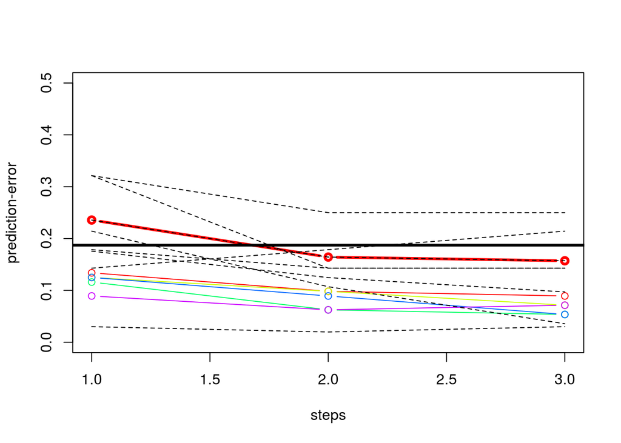

[1] “Prediction error at end is: 0.235714285714286” [2] “Prediction error at end is: 0.164285714285714” [3] “Prediction error at end is: 0.157142857142857”

| k 1 | k 2 | k 3 | k 4 | k 5 |
| --- | --- | --- | --- | --- |
| profc_ws23_hr_hr | longc_DTM_50m_avg_ws11_50m | maxic_DTM_50m_avg_ws11_50m | crosc_ws19_hr_hr | profc_ws7_10m |
| profc_ws15_10m | Maximal_Curvature_50m | minic_ws23_hr_hr | minic_ws11_10m | minic_ws5_10m |
| slope_DTM_50m_avg_ws9_50m | minic_ws29_hr_hr | Total_Curvature_50m | TangentialCurvature_10m | profc_ws5_10m |

[1] “OBB error with all predictors of localterrain is 0.121428571428571”

|  | SB | SD | MeanDecreaseAccuracy | MeanDecreaseGini |
| --- | --- | --- | --- | --- |
| profc_DTM_50m_avg_ws11_50m | 0.0134841 | 0.0047076 | 0.0060268 | 1.2236807 |
| longc_DTM_50m_avg_ws11_50m | 0.0154583 | 0.0043669 | 0.0059469 | 1.0729160 |
| maxic_DTM_50m_avg_ws11_50m | 0.0139895 | 0.0035238 | 0.0049554 | 0.8382279 |
| slope_ws19_hr_hr | 0.0016635 | 0.0045583 | 0.0041773 | 0.2126311 |
| minic_ws29_hr_hr | 0.0139162 | 0.0021690 | 0.0039040 | 0.9184923 |
| longc_DTM_50m_avg_ws3_50m | 0.0078778 | 0.0023873 | 0.0032471 | 0.9272481 |
| profc_DTM_50m_avg_ws9_50m | 0.0039620 | 0.0031603 | 0.0032454 | 0.6885254 |
| longc_DTM_50m_avg_ws5_50m | 0.0094062 | 0.0022233 | 0.0031305 | 0.8263338 |
| profc_DTM_50m_avg_ws5_50m | 0.0055849 | 0.0023853 | 0.0027675 | 0.7227586 |
| Total_Curvature_50m | 0.0044437 | 0.0023915 | 0.0026738 | 0.5026866 |

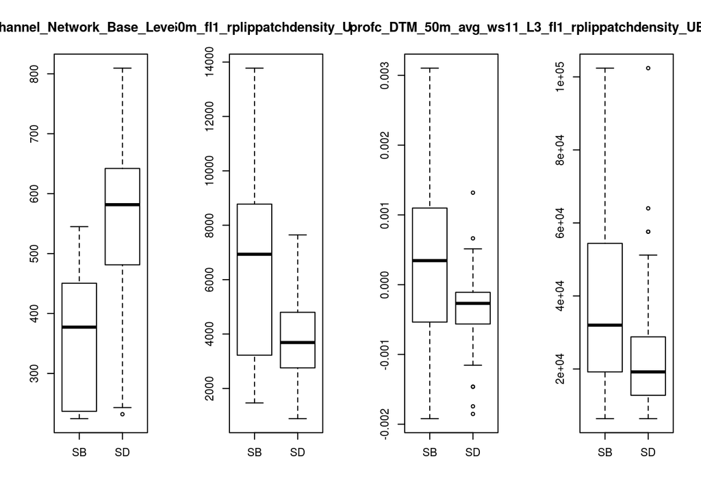

How does this compare to the differences between the units on the geological map?

[1] “OBB error with all predictors of allpreds is 0.13828967642527”

|  | SB | SD | MeanDecreaseAccuracy | MeanDecreaseGini |
| --- | --- | --- | --- | --- |
| Catchment_slope_50m | 0.0181183 | 0.0122041 | 0.0154899 | 24.93344 |
| elev_ws3_10m | 0.0111904 | 0.0156469 | 0.0131720 | 34.92865 |
| Channel_Network_Base_Level_hr | 0.0098353 | 0.0152175 | 0.0122326 | 29.23796 |
| elev_ws5_10m | 0.0106543 | 0.0133521 | 0.0118565 | 29.54890 |
| ChannelNetworkBaseLevel_10m | 0.0087125 | 0.0152643 | 0.0116249 | 25.86974 |
| elev_ws11_10m | 0.0100396 | 0.0135576 | 0.0115993 | 26.97074 |
| slope_DTM_50m_avg_ws11_50m | 0.0065382 | 0.0177979 | 0.0115672 | 17.19878 |
| elev_ws15_10m | 0.0100286 | 0.0132758 | 0.0114632 | 28.01368 |
| slope_DTM_50m_avg_ws9_50m | 0.0044175 | 0.0161425 | 0.0096328 | 13.32035 |
| longc_DTM_50m_avg_ws11_50m | 0.0066422 | 0.0086657 | 0.0075746 | 25.65712 |

[1] “OBB error with all predictors of roughness is 0.227097767513472”

|  | SB | SD | MeanDecreaseAccuracy | MeanDecreaseGini |
| --- | --- | --- | --- | --- |
| Texture_50m | 0.0037181 | 0.0128066 | 0.0077938 | 20.472704 |
| TRI_hr_ws17 | 0.0099696 | 0.0039105 | 0.0072542 | 12.606635 |
| TRI_hr_ws50 | 0.0052523 | 0.0086253 | 0.0067247 | 10.336837 |
| TRI_hr_ws47 | 0.0072202 | 0.0061220 | 0.0067189 | 10.527037 |
| TRI_hr_ws24 | 0.0082494 | 0.0040632 | 0.0063597 | 9.290969 |
| TRI_hr_ws25 | 0.0078361 | 0.0044505 | 0.0063481 | 10.838773 |
| TRI_hr_ws48 | 0.0047218 | 0.0083180 | 0.0063049 | 10.490035 |
| TRI_hr_ws30 | 0.0094262 | 0.0023013 | 0.0062640 | 7.696654 |
| geom_hr_L50m_fl10_rpliprichness_UE_hr_60cells_hr | 0.0018890 | 0.0114992 | 0.0061667 | 13.819228 |
| TRI_hr_ws14 | 0.0069376 | 0.0051791 | 0.0061250 | 11.985104 |

[1] “OBB error with all predictors of localterrain is 0.164936562860438”

|  | SB | SD | MeanDecreaseAccuracy | MeanDecreaseGini |
| --- | --- | --- | --- | --- |
| slope_DTM_50m_avg_ws11_50m | 0.0166139 | 0.0458405 | 0.0297169 | 44.76730 |
| slope_DTM_50m_avg_ws9_50m | 0.0168301 | 0.0352361 | 0.0250123 | 39.75654 |
| slope_DTM_50m_avg_ws7_50m | 0.0136592 | 0.0234748 | 0.0181040 | 33.04658 |
| longc_DTM_50m_avg_ws11_50m | 0.0091829 | 0.0228266 | 0.0153019 | 48.42648 |
| profc_DTM_50m_avg_ws11_50m | 0.0083675 | 0.0229203 | 0.0148422 | 43.28877 |
| slope_DTM_50m_avg_ws5_50m | 0.0125694 | 0.0158080 | 0.0140195 | 23.41930 |
| longc_DTM_50m_avg_ws9_50m | 0.0105544 | 0.0180521 | 0.0138688 | 37.59578 |
| longc_DTM_50m_avg_ws5_50m | 0.0120093 | 0.0147764 | 0.0132765 | 21.60656 |
| profc_DTM_50m_avg_ws9_50m | 0.0112980 | 0.0155178 | 0.0132251 | 34.73222 |
| slope_DTM_50m_avg_ws3_50m | 0.0130498 | 0.0112695 | 0.0122455 | 19.89704 |

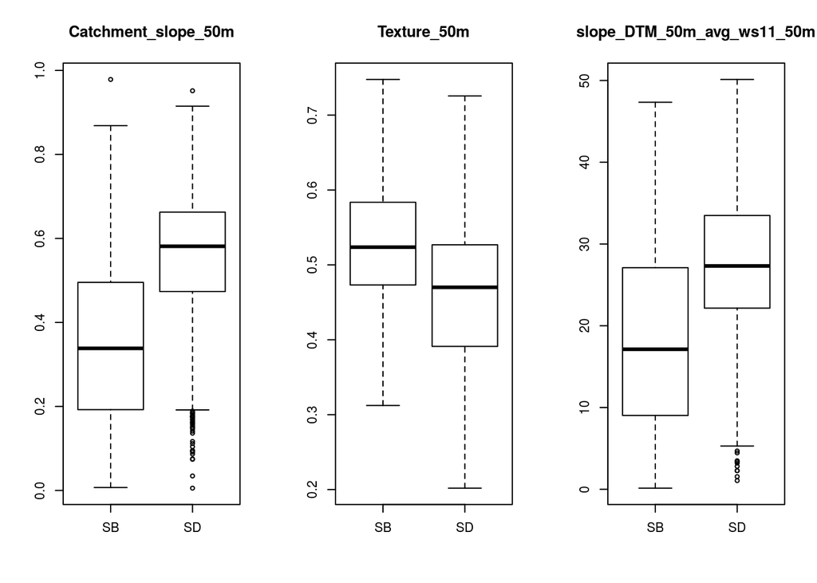